# Project: Investigate a Dataset - No Show Appointment

- Introduction
- Questions to be answered
- Data Wrangling
- Exploratory Data Analysis
- Conclusions

## Introduction

This dataset collects information from 100k medical appointments in Brazil and is focused on the question of whether or not patients show up for their appointment. We want to know what affects the patient not showing up on his appointment.

```python
import pandas as pd
import numpy as np
import matplotlib.pyplot as plt
import seaborn as sns
%matplotlib inline

sns.set_style('darkgrid')
sns.set_palette("muted")
```

## Questions to be answered

- What percentages of males and females have shown up for their appointment?
- What percentages of males and females have not shown up for their appointment?
- What is the trend in times for patients who show up and not show up?
- Does scholarship affect the patient decision to attend the appointment?
- Does a certain age not show up more than other ages?
- Does sending an SMS increase the probability of showing up?
- Does where a person live affect their showing up?

## Data Wrangling

### General Properties

```python
df = pd.read_csv("noshowappointments-kagglev2-may-2016.csv")
df.head(3)
```

|  | PatientId | AppointmentID | Gender | ScheduledDay | AppointmentDay | Age | Neighbourhood | Scholarship | Hipertension | Diabetes | Alcoholism | Handcap | SMS_received | No-show |
| --- | --- | --- | --- | --- | --- | --- | --- | --- | --- | --- | --- | --- | --- | --- |
| 0 | 29872499824296.00 | 5642903 | F | 2016-04-29T18:38:08Z | 2016-04-29T00:00:00Z | 62 | JARDIM DA PENHA | 0 | 1 | 0 | 0 | 0 | 0 | No |
| 1 | 558997776694438.00 | 5642503 | M | 2016-04-29T16:08:27Z | 2016-04-29T00:00:00Z | 56 | JARDIM DA PENHA | 0 | 0 | 0 | 0 | 0 | 0 | No |
| 2 | 4262962299951.00 | 5642549 | F | 2016-04-29T16:19:04Z | 2016-04-29T00:00:00Z | 62 | MATA DA PRAIA | 0 | 0 | 0 | 0 | 0 | 0 | No |

```python
df.info()
print('--------------')
print('Dataframe contains {} rows and {} columns'.format(df.shape[0],df.shape[1]))
```

```
<class 'pandas.core.frame.DataFrame'>
RangeIndex: 110527 entries, 0 to 110526
Data columns (total 14 columns):
 #   Column          Non-Null Count   Dtype
---  ------          --------------   -----
 0   PatientId       110527 non-null  float64
 1   AppointmentID   110527 non-null  int64
 2   Gender          110527 non-null  object
 3   ScheduledDay    110527 non-null  object
 4   AppointmentDay  110527 non-null  object
 5   Age             110527 non-null  int64
 6   Neighbourhood   110527 non-null  object
 7   Scholarship     110527 non-null  int64
 8   Hipertension    110527 non-null  int64
 9   Diabetes        110527 non-null  int64
 10  Alcoholism      110527 non-null  int64
 11  Handcap         110527 non-null  int64
 12  SMS_received    110527 non-null  int64
 13  No-show         110527 non-null  object
dtypes: float64(1), int64(8), object(5)
memory usage: 11.8+ MB
--------------
Dataframe contains 110527 rows and 14 columns
```

**Inspect the type of some columns**

```python
type(df["ScheduledDay"][0]), type(df["AppointmentDay"][0]), type(df["Gender"][0])
```

```
(str, str, str)
```

**Check for null values**

```python
df.isnull().sum().any()
```

```
False
```

**Check for duplicate rows**

```python
df.duplicated().any()
```

```
False
```

**Check how many patients showed up for the appointment**

```python
show_count = df["No-show"].value_counts()
show_count
```

```
No     88208
Yes    22319
Name: No-show, dtype: int64
```

**Check how many male and female patients**

```python
gender_count = df["Gender"].value_counts()
gender_count
```

```
F    71840
M    38687
Name: Gender, dtype: int64
```

### Impressions after inspecting the dataset:

- There's no null values and no duplicates in the dataset.
- Columns like (Hipertension, Diabetes, Alcoholism, Handcap) are not useful for us and will be dropped.
- Column PatientId type will be changed from float to int.
- Columns like ScheduledDay, AppointmentDay need their type to be changed to datetime.
- Columns' names are in good format and doesn't need to be renamed.

### Data Cleaning

**Drop unused column (Hipertension, Diabetes, Alcoholism, Handcap)**

```python
labels_drop = ["Hipertension", "Diabetes", "Alcoholism", "Handcap"]
df.drop(labels_drop, axis=1, inplace=True)
```

**Change PatientID column type to int**

```python
df["PatientId"] = df["PatientId"].astype(int)
```

**Change ScheduledDay, AppointmentDay columns type to datetime**

```python
df['ScheduledDay'] = pd.to_datetime(df["ScheduledDay"])
df['AppointmentDay'] = pd.to_datetime(df["AppointmentDay"])
```

```python
df.info()
```

```
<class 'pandas.core.frame.DataFrame'>
RangeIndex: 110527 entries, 0 to 110526
Data columns (total 10 columns):
 #   Column          Non-Null Count   Dtype
---  ------          --------------   -----
 0   PatientId       110527 non-null  int64
 1   AppointmentID   110527 non-null  int64
 2   Gender          110527 non-null  object
 3   ScheduledDay    110527 non-null  datetime64[ns, UTC]
 4   AppointmentDay  110527 non-null  datetime64[ns, UTC]
 5   Age             110527 non-null  int64
 6   Neighbourhood   110527 non-null  object
 7   Scholarship     110527 non-null  int64
 8   SMS_received    110527 non-null  int64
 9   No-show         110527 non-null  object
dtypes: datetime64[ns, UTC](2), int64(5), object(3)
memory usage: 8.4+ MB
```

> Now the dataset is ready for data analysis

## Exploratory Data Analysis

### Research Question 1 : What percentages of males and females have shown up for their appointment?

```python
df_show = df[df["No-show"] == "No"]
```

```python
genders_num = df_show["Gender"].value_counts()
genders_num
```

```
F    57246
M    30962
Name: Gender, dtype: int64
```

```python
male_percent = (genders_num["M"]/ gender_count["M"]) * 100
female_percent = (genders_num["F"]/ gender_count["F"]) * 100
print("{:.2f} percent of males didn't attend their appointment".format(male_percent))
print("{:.2f} percent of females didn't attend their appointment".format(female_percent))
```

```
80.03 percent of males didn't attend their appointment
79.69 percent of females didn't attend their appointment
```

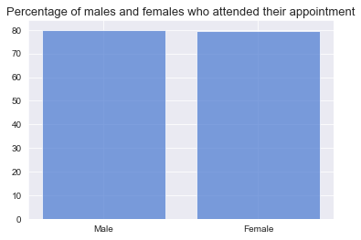

```python
plt.bar(["Male", "Female"], [male_percent, female_percent], alpha= 0.7)
plt.title("Percentage of males and females who attended their appointment",fontsize=13)
plt.show()
```

### Research Question 2 : What percentages of males and females have not shown up for their appointment?

```python
df_no_show = df[df["No-show"] == "Yes"]
```

```python
genders_num_n = df_no_show["Gender"].value_counts()
genders_num_n
```

```
F    14594
M     7725
Name: Gender, dtype: int64
```

```python
male_percent = (genders_num_n["M"]/ gender_count["M"]) * 100
female_percent = (genders_num_n["F"]/ gender_count["F"]) * 100
print("{:.2f} percent of males didn't attend their appointment".format(male_percent))
print("{:.2f} percent of females didn't attend their appointment".format(female_percent))
```

```
19.97 percent of males didn't attend their appointment
20.31 percent of females didn't attend their appointment
```

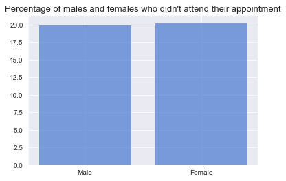

```python
plt.bar(["Male", "Female"], [male_percent, female_percent], alpha= 0.7)
plt.title("Percentage of males and females who didn't attend their appointment",fontsize=13)
plt.show()
```

**From the previous 2 questions, it is clear that the gender doesn't reflect whether the patient will show up for the appointment or not**

### Research Question 3 : Does scholarship affect the patient decision to attend the appointment?

```python
df_schol = df[df["Scholarship"] == 1]
```

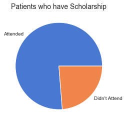

```python
plt.pie(df_schol["No-show"].value_counts(), labels = ["Attended", "Didn't Attend"])
plt.title("Patients who have Scholarship", fontsize=14)
plt.show()
```

```python
df_no_schol = df[df["Scholarship"] == 0]
```

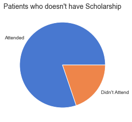

```python
plt.pie(df_no_schol["No-show"].value_counts(), labels = ["Attended", "Didn't Attend"])
plt.title("Patients who doesn't have Scholarship", fontsize=14)
plt.show()
```

Inspecting the 2 pie charts, we notice that having a scholarship decreases the probability of attending by a small percentage.

### Research Question 4 : What is the trend in times for patients who show up and not show up?

```python
df_no_show.AppointmentDay.dt.dayofweek.value_counts()
```

```
1    5152
2    5093
0    4690
4    4037
3    3338
5       9
Name: AppointmentDay, dtype: int64
```

```python
hour_bins = sorted(df.ScheduledDay.dt.hour.unique())
```

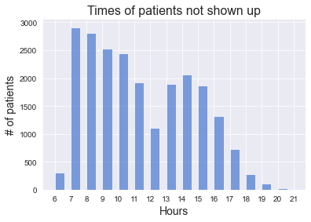

```python
plt.hist(df_no_show.ScheduledDay.dt.hour, bins=hour_bins, alpha=0.7, width=0.6 );
plt.xlabel("Hours", fontsize=14)
plt.ylabel("# of patients", fontsize=14)
plt.xticks(hour_bins)
plt.title("Times of patients not shown up", fontsize=16)
plt.show()
```

This histogram shows the times that patients who did not show up for their schedule. We notice that the peak in the morning at 7AM and it gradually decreases.

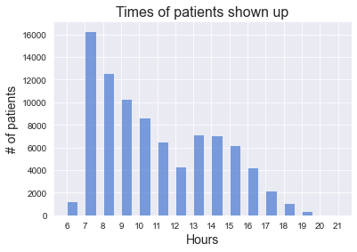

```python
plt.hist(df_show.ScheduledDay.dt.hour, bins=hour_bins, alpha=0.7, width=0.6 );
plt.xlabel("Hours", fontsize=14)
plt.ylabel("# of patients", fontsize=14)
plt.xticks(hour_bins)
plt.title("Times of patients shown up", fontsize=16)
plt.show()
```

We can see from the histogram that the peak time is 7AM for the patients who show up and the number of patients decrease as the hour goes on.

### Research Question 5 : Does a certain age not show up more than other ages?

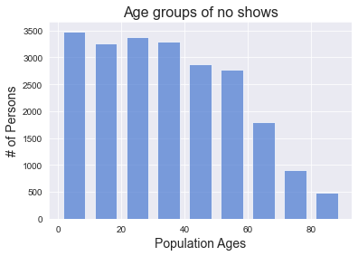

```python
bins = [0,10,20,30,40,50,60,70,80,90]

plt.hist(df_no_show.Age,bins=bins,histtype='bar',rwidth=0.7, alpha = 0.7)
plt.xlabel('Population Ages',fontsize=14)
plt.ylabel('# of Persons',fontsize=14)
plt.title('Age groups of no shows',fontsize=16)

plt.show()
```

### Research Question 6 : Does sending an SMS increase the probability of showing up?

```python
df_SMS = df[df["SMS_received"] == 1]
```

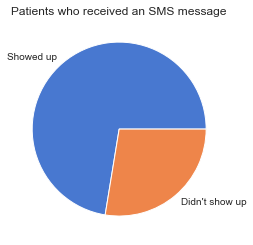

```python
plt.pie(df_SMS["No-show"].value_counts(), labels=["Showed up", "Didn't show up"])
plt.title("Patients who received an SMS message")
plt.show()
```

```python
df_no_SMS = df[df["SMS_received"] == 0]
```

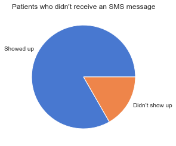

```python
plt.pie(df_no_SMS["No-show"].value_counts(), labels=["Showed up", "Didn't show up"])
plt.title("Patients who didn't receive an SMS message")
plt.show()
```

Sending a message doesn't increase the probability of attending the appointment at all, from the 2 pie charts we notice that the patients who received an SMS didn't attend the appointment more than the patients who didn't receive an SMS.

### Research Question 7 : Does where a person live affect their showing up?

plot number of patients and their neighbourhood who doesn't show up in their appointment

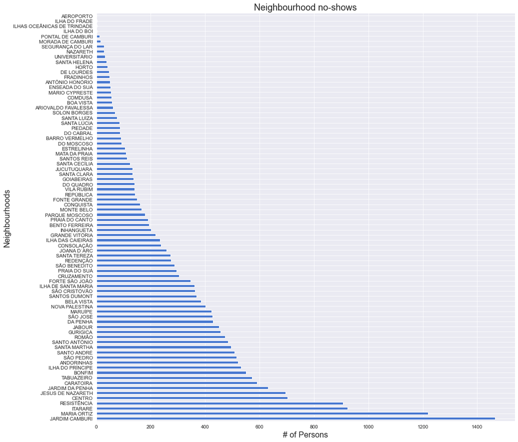

```python
df_no_show["Neighbourhood"].value_counts().plot(kind="barh", figsize=(15,15))
plt.ylabel('Neighbourhoods',fontsize=16);
plt.xlabel('# of Persons', fontsize=16);
plt.title('Neighbourhood no-shows',fontsize=18);
```

By inspecting the above chart we see that the "JARDIM CAMBURI" neighbourhood have the highest number of patients not showing up on their appointment.

We will calculate now the percentage of patients that doesn't show up from these neighbour hoods.

```python
neighbourhood_percentage = (df_no_show["Neighbourhood"].value_counts())/(df["Neighbourhood"].value_counts()) * 100
```

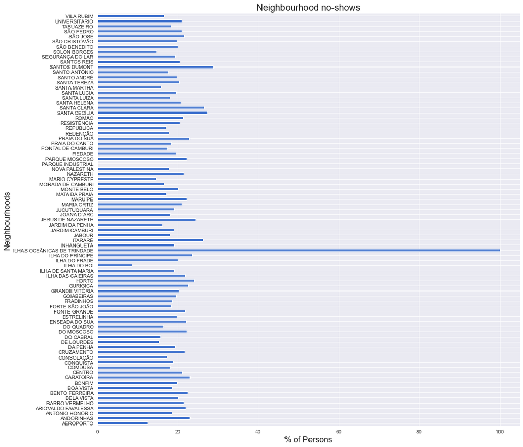

```python
neighbourhood_percentage.plot(kind="barh", figsize=(15,15))
plt.ylabel('Neighbourhoods',fontsize=16);
plt.xlabel('% of Persons', fontsize=16);
plt.title('Neighbourhood no-shows',fontsize=18);
```

From the above chart, we see that patients from a neighbourhood like "ILHAS OCEANICAS DE TRINDADE" have a percentage of 100% of not attending their appointment.

## Conclusions

- Questions 1 and 2, show that gender doesn't play a role in patient attending/not attending his appointment.
- Question 3 shows that patients with scholarships are more likely to not show up on their appointment.
- Question 4 shows that patients are more likely to attend/not attend their appointment on 7AM (peak time) and it gradually decreases.
- Question 5 shows that younger patients are more likely to not show up on their appointment, old patients are more likely to show up on their appointment.
- Question 6 shows that sending an SMS message to patients doesn't increase the percentage of showing up on the appointment, but even more in this dataset, the patients who have received as SMS message didn't show up more than the patients who didn't receive an SMS.
- Question 7 shows that the neighbourhood area affects the showing/not showing up of the patient on the appointment.